# ELE618 - Sistemas Elétricos Industriais

Instalações Elétricas - Ademaro A. M. B. Cotrim  
Capítulo 1 - Fundamentos

Prof. Dr. Thales A. C. Maia

UFMG - DEE

# Conceitos Básicos

## Circuito e Sistema Elétrico

- **Circuito elétrico:** conjunto de corpos, componentes ou meios no qual é possível que haja corrente elétrica.
- **Sistema elétrico:** circuito ou conjunto de circuitos inter-relacionados constituído para determinada finalidade, formado por componentes que conduzem corrente.

## Instalação Elétrica

- Inclui componentes que não conduzem corrente, mas são essenciais ao funcionamento (condutos, caixas, suportes).
- É o sistema elétrico físico: conjunto coordenado composto para um fim específico.
- A cada instalação elétrica corresponderá um sistema elétrico.

# Norma NBR 5410

## Instalações de Baixa Tensão

- Aplica-se a instalações elétricas cuja tensão nominal é igual ou inferior a **1.000 V em CA** ou **1.500 V em CC**.
- Fixa condições para garantir: funcionamento adequado, segurança de pessoas e animais, e conservação de bens.

## Aplicações da NBR 5410

- Edificações residenciais e comerciais em geral.
- Estabelecimentos institucionais e de uso público.
- Estabelecimentos industriais e agropecuários.
- Instalações temporárias (canteiros de obras, feiras).

# Componentes das Instalações

## Equipamento e Dispositivo

- **Equipamento Elétrico:** Unidade funcional que exerce funções de geração, transmissão, distribuição ou utilização de energia.
- **Dispositivo Elétrico:** Equipamento integrante de um circuito com funções de Manobra, Comando, Proteção e Controle.

## Esquemas Típicos de Instalações

- **Quadro Principal:** Recebe energia da origem da instalação e a distribui para outros circuitos ou quadros.
- **Quadro Terminal:** Alimenta exclusivamente circuitos terminais.

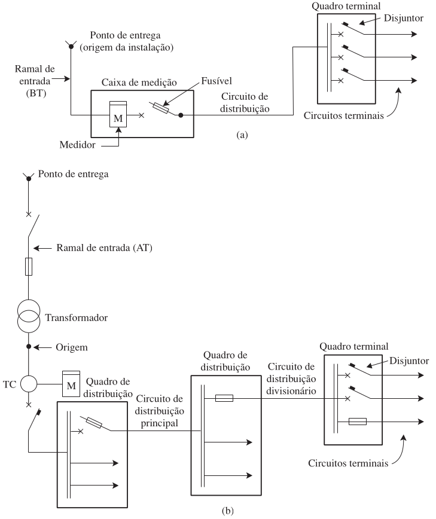

Fig. 1: Esquemas típicos de instalações: (a) alimentação por rede pública BT; (b) alimentação por rede pública AT (Cotrim, 2009).

## Distribuição Radial

Normalmente as instalações utilizam distribuições radiais, onde podemos distinguir:

- **Circuitos de distribuição:** Principais ou divisionários, interligando os quadros.
- **Circuitos terminais:** Protegidos pelo último dispositivo de proteção.

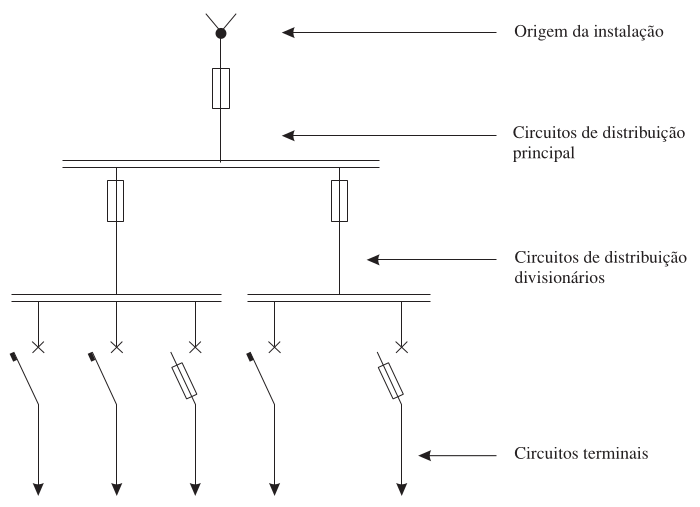

Fig. 2: Distribuição radial: circuitos de distribuição e terminais (Cotrim, 2009).

## Esquemas de Condutores Vivos

De acordo com a NBR 5410, os sistemas de alimentação podem ser definidos pelos seus condutores vivos (fases e neutro). Os esquemas variam desde monofásicos a dois condutores até trifásicos com neutro.

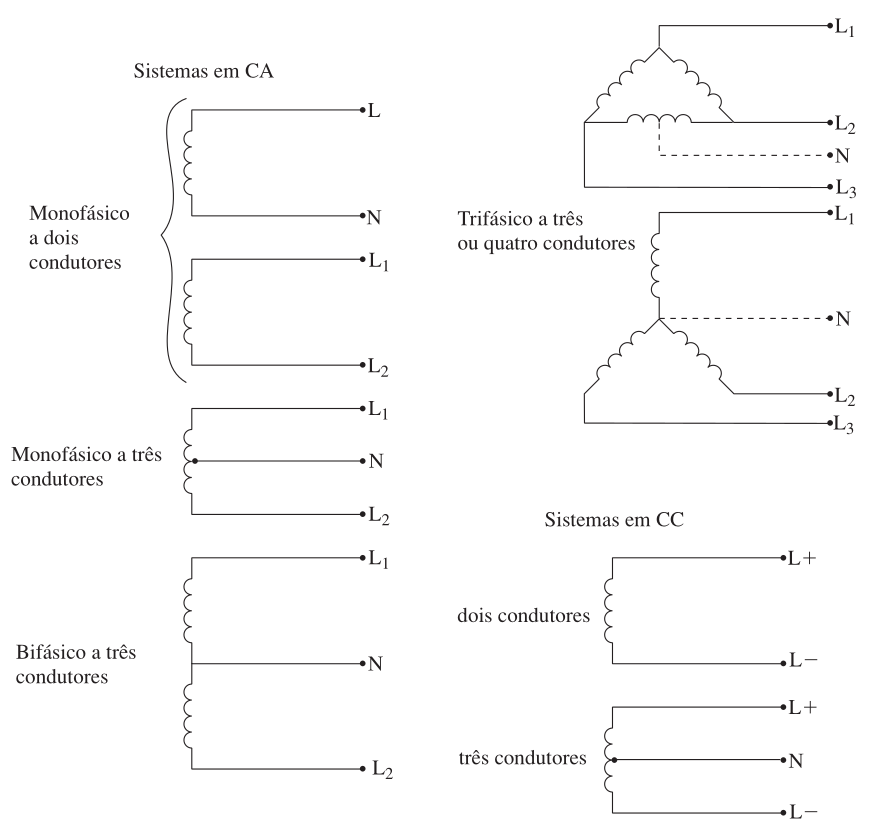

Fig. 3: Esquemas de condutores vivos segundo a NBR 5410 (Cotrim, 2009).

# Grandezas e Definições

## Carga e Potência

- **Carga elétrica:** equipamento que absorve potência ativa. Podem ser *lineares* ou *não-lineares* (eletrônicos que distorcem a onda).
- **Potência instalada:** soma das potências nominais dos equipamentos de utilização de uma instalação.

## Faltas e Correntes

- **Falta elétrica:** contato acidental entre partes com potenciais diferentes (curto-circuito) ou para a terra.
- **Sobrecarga:** corrente que excede o valor nominal sem que haja uma falta elétrica.
- **Corrente de fuga:** corrente muito pequena que percorre um caminho diferente do previsto através da isolação.

## Corrente Diferencial-Residual ($i_{DR}$)

É a soma vetorial (ou dos valores instantâneos) das correntes que percorrem **todos os condutores vivos** do circuito considerado.

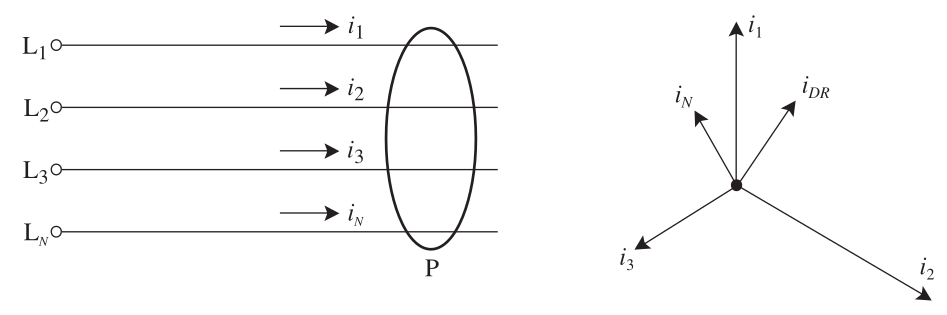

Fig. 4: Corrente diferencial-residual (Cotrim, 2009).

Na ausência de fuga para a terra, a $i_{DR}$ deve ser zero.

# Tensões e Choque Elétrico

## Tensões Elétricas (Tabelas 1.1 e 1.2)

Tensões nominais da norma (IEC) e as mais usuais no Brasil.

| Sistema | Tensão Nominal (V) |
| --- | --- |
| **IEC 60Hz 3-fases** | 230/400, 277/480, 480/690 |
| **Brasil 3-fases** | 127/220, 220/380, 254/440 |
| **Brasil Monofásico** | 115/230, 127/254 |

## Tensões Elétricas (Tabelas 1.3 a 1.5)

| Equipamentos (Tab 1.3) | Alta Tensão (Tab 1.4/1.5) |
| --- | --- |
| 110, 115, 120, 127, 220 V | Redes: 13,8 kV, 34,5 kV |
| 380, 440 V (Trifásicos) | Suportam até 36,5 kV |

## Choque Elétrico

Perturbação no organismo quando percorrido por corrente.

- **Contato direto:** A pessoa toca partes que estão normalmente energizadas (falta de isolamento ou imprudência).
- **Contato indireto:** A pessoa toca em uma carcaça (massa) que ficou acidentalmente sob tensão devido a um defeito.

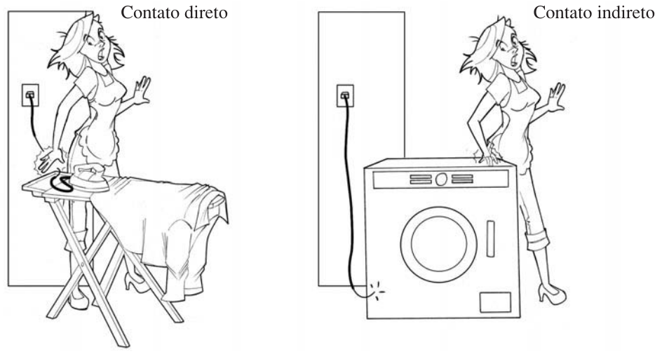

Contatos direto e indireto (Cotrim, 2009).

# Referências

COTRIM, Ademaro A. M. B. **Instalações Elétricas**. 5ª Edição. São Paulo: Pearson Prentice Hall, 2009.

# Exercícios

## Exercício 1

**Quais são as principais funções exercidas pelos dispositivos elétricos?**

Manobra, comando, proteção e controle.

## Exercício 2

**Qual é a definição da potência instalada de uma instalação elétrica?**

É a soma das potências nominais de todos os equipamentos de utilização da instalação (ou de um setor dela).

## Exercício 3

**Quais tipos de sobrecorrente podem ocorrer em uma instalação elétrica?**

Correntes de sobrecarga (sem que haja falta elétrica) e correntes de curto-circuito (corrente de falta).

## Exercício 4

**Como se define a baixa tensão?**

É a tensão nominal igual ou inferior a 1.000 V em corrente alternada (CA) ou a 1.500 V em corrente contínua (CC).

## Exercício 5

**O que é um choque elétrico?**

É a perturbação, de natureza e efeitos diversos, que se manifesta no organismo humano ou animal quando este é percorrido por uma corrente elétrica.

## Exercício 6

**Defina ramal de ligação.**

É o conjunto de condutores e acessórios instalados entre o ponto de derivação da rede da concessionária e o ponto de entrega da instalação.

## Exercício 7

**Quais são os três tipos de instalação temporária considerados pela NBR 5410?**

1. Locais de acampamento e marinas; (2) Canteiros de obras; e (3) Feiras, exposições e análogos.

## Exercício 8

**Calcule a corrente nominal de um motor trifásico de 30 CV, 440 V, rendimento 0,9 e FP 0,8.**

**Código**

```julia
# Dados do motor
potencia_cv = 30
V = 440
rend = 0.90
fp = 0.80

# Conversão CV para Watts (1 CV = 736 W)
potencia_w = potencia_cv * 736

# Cálculo da Corrente (Sistema Trifásico)
I = potencia_w / (sqrt(3) * V * rend * fp)
println("Corrente Nominal: ", round(I, digits=2), " A")
# Saída: Corrente Nominal: 40.24 A
```

```
Corrente Nominal: 40.24 A
```

## Exercício 9

**Determine a corrente de um forno elétrico de 3 kW, monofásico, rendimento 70% em 220 V.**

**Código**

```julia
# Dados do forno
pot_saida_kw = 3
V = 220
rend = 0.70
fp = 1.0  # Forno elétrico resistivo

# Cálculo da Potência Absorvida em Watts
pot_abs_w = (pot_saida_kw * 1000) / rend

# Cálculo da Corrente (Sistema Monofásico)
I = pot_abs_w / (V * fp)
println("Corrente do Forno: ", round(I, digits=2), " A")
# Saída: Corrente do Forno: 19.48 A
```

```
Corrente do Forno: 19.48 A
```

## Exercício 10

**Quais são as categorias dos parâmetros de influências externas na NBR 5410?**

(1) Condições ambientais; (2) Condições de utilização; e (3) Construção das edificações.

# Obrigado!

http://thalesmaia.com/